# R Notebook

# (a) For each predictor, fit a simple linear regression model using a single variable to predict the response. In which of these models is there a statistically significant relationship between the predictor and the response? Plot the figure of relationship between medv and lstat as an example to validate your finding.

```r
boston <- read.csv("Boston.csv")
model1 <-  lm(medv ~ crim, boston)
model2 <-  lm(medv ~ zn, boston)
model3 <-  lm(medv ~ indus, boston)
model4 <-  lm(medv ~ chas, boston)
model5 <-  lm(medv ~ nox, boston)
model6 <-  lm(medv ~ rm, boston)
model7 <-  lm(medv ~ age, boston)
model8 <-  lm(medv ~ dis, boston)
model9 <-  lm(medv ~ rad, boston)
model10 <-  lm(medv ~ tax, boston)
model11 <-  lm(medv ~ ptratio, boston)
model12 <-  lm(medv ~ black, boston)
model13 <-  lm(medv ~ lstat, boston)
summary(model1)
```

```
Call:
lm(formula = medv ~ crim, data = boston)

Residuals:
    Min      1Q  Median      3Q     Max
-16.957  -5.449  -2.007   2.512  29.800

Coefficients:
            Estimate Std. Error t value Pr(>|t|)
(Intercept) 24.03311    0.40914   58.74   <2e-16 ***
crim        -0.41519    0.04389   -9.46   <2e-16 ***
---
Signif. codes:  0 '***' 0.001 '**' 0.01 '*' 0.05 '.' 0.1 ' ' 1

Residual standard error: 8.484 on 504 degrees of freedom
Multiple R-squared:  0.1508,    Adjusted R-squared:  0.1491
F-statistic: 89.49 on 1 and 504 DF,  p-value: < 2.2e-16
```

```r
summary(model2)
```

```
Call:
lm(formula = medv ~ zn, data = boston)

Residuals:
    Min      1Q  Median      3Q     Max
-15.918  -5.518  -1.006   2.757  29.082

Coefficients:
            Estimate Std. Error t value Pr(>|t|)
(Intercept) 20.91758    0.42474  49.248   <2e-16 ***
zn           0.14214    0.01638   8.675   <2e-16 ***
---
Signif. codes:  0 '***' 0.001 '**' 0.01 '*' 0.05 '.' 0.1 ' ' 1

Residual standard error: 8.587 on 504 degrees of freedom
Multiple R-squared:  0.1299,    Adjusted R-squared:  0.1282
F-statistic: 75.26 on 1 and 504 DF,  p-value: < 2.2e-16
```

```r
summary(model3)
```

```
Call:
lm(formula = medv ~ indus, data = boston)

Residuals:
    Min      1Q  Median      3Q     Max
-13.017  -4.917  -1.457   3.180  32.943

Coefficients:
            Estimate Std. Error t value Pr(>|t|)
(Intercept) 29.75490    0.68345   43.54   <2e-16 ***
indus       -0.64849    0.05226  -12.41   <2e-16 ***
---
Signif. codes:  0 '***' 0.001 '**' 0.01 '*' 0.05 '.' 0.1 ' ' 1

Residual standard error: 8.057 on 504 degrees of freedom
Multiple R-squared:  0.234, Adjusted R-squared:  0.2325
F-statistic:   154 on 1 and 504 DF,  p-value: < 2.2e-16
```

```r
summary(model4)
```

```
Call:
lm(formula = medv ~ chas, data = boston)

Residuals:
    Min      1Q  Median      3Q     Max
-17.094  -5.894  -1.417   2.856  27.906

Coefficients:
            Estimate Std. Error t value Pr(>|t|)
(Intercept)  22.0938     0.4176  52.902  < 2e-16 ***
chas          6.3462     1.5880   3.996 7.39e-05 ***
---
Signif. codes:  0 '***' 0.001 '**' 0.01 '*' 0.05 '.' 0.1 ' ' 1

Residual standard error: 9.064 on 504 degrees of freedom
Multiple R-squared:  0.03072,   Adjusted R-squared:  0.02879
F-statistic: 15.97 on 1 and 504 DF,  p-value: 7.391e-05
```

```r
summary(model5)
```

```
Call:
lm(formula = medv ~ nox, data = boston)

Residuals:
    Min      1Q  Median      3Q     Max
-13.691  -5.121  -2.161   2.959  31.310

Coefficients:
            Estimate Std. Error t value Pr(>|t|)
(Intercept)   41.346      1.811   22.83   <2e-16 ***
nox          -33.916      3.196  -10.61   <2e-16 ***
---
Signif. codes:  0 '***' 0.001 '**' 0.01 '*' 0.05 '.' 0.1 ' ' 1

Residual standard error: 8.323 on 504 degrees of freedom
Multiple R-squared:  0.1826,    Adjusted R-squared:  0.181
F-statistic: 112.6 on 1 and 504 DF,  p-value: < 2.2e-16
```

```r
summary(model6)
```

```
Call:
lm(formula = medv ~ rm, data = boston)

Residuals:
    Min      1Q  Median      3Q     Max
-23.346  -2.547   0.090   2.986  39.433

Coefficients:
            Estimate Std. Error t value Pr(>|t|)
(Intercept)  -34.671      2.650  -13.08   <2e-16 ***
rm             9.102      0.419   21.72   <2e-16 ***
---
Signif. codes:  0 '***' 0.001 '**' 0.01 '*' 0.05 '.' 0.1 ' ' 1

Residual standard error: 6.616 on 504 degrees of freedom
Multiple R-squared:  0.4835,    Adjusted R-squared:  0.4825
F-statistic: 471.8 on 1 and 504 DF,  p-value: < 2.2e-16
```

```r
summary(model7)
```

```
Call:
lm(formula = medv ~ age, data = boston)

Residuals:
    Min      1Q  Median      3Q     Max
-15.097  -5.138  -1.958   2.397  31.338

Coefficients:
            Estimate Std. Error t value Pr(>|t|)
(Intercept) 30.97868    0.99911  31.006   <2e-16 ***
age         -0.12316    0.01348  -9.137   <2e-16 ***
---
Signif. codes:  0 '***' 0.001 '**' 0.01 '*' 0.05 '.' 0.1 ' ' 1

Residual standard error: 8.527 on 504 degrees of freedom
Multiple R-squared:  0.1421,    Adjusted R-squared:  0.1404
F-statistic: 83.48 on 1 and 504 DF,  p-value: < 2.2e-16
```

```r
summary(model8)
```

```
Call:
lm(formula = medv ~ dis, data = boston)

Residuals:
    Min      1Q  Median      3Q     Max
-15.016  -5.556  -1.865   2.288  30.377

Coefficients:
            Estimate Std. Error t value Pr(>|t|)
(Intercept)  18.3901     0.8174  22.499  < 2e-16 ***
dis           1.0916     0.1884   5.795 1.21e-08 ***
---
Signif. codes:  0 '***' 0.001 '**' 0.01 '*' 0.05 '.' 0.1 ' ' 1

Residual standard error: 8.914 on 504 degrees of freedom
Multiple R-squared:  0.06246,   Adjusted R-squared:  0.0606
F-statistic: 33.58 on 1 and 504 DF,  p-value: 1.207e-08
```

```r
summary(model9)
```

```
Call:
lm(formula = medv ~ rad, data = boston)

Residuals:
    Min      1Q  Median      3Q     Max
-17.770  -5.199  -1.967   3.321  33.292

Coefficients:
            Estimate Std. Error t value Pr(>|t|)
(Intercept) 26.38213    0.56176  46.964   <2e-16 ***
rad         -0.40310    0.04349  -9.269   <2e-16 ***
---
Signif. codes:  0 '***' 0.001 '**' 0.01 '*' 0.05 '.' 0.1 ' ' 1

Residual standard error: 8.509 on 504 degrees of freedom
Multiple R-squared:  0.1456,    Adjusted R-squared:  0.1439
F-statistic: 85.91 on 1 and 504 DF,  p-value: < 2.2e-16
```

```r
summary(model10)
```

```
Call:
lm(formula = medv ~ tax, data = boston)

Residuals:
    Min      1Q  Median      3Q     Max
-14.091  -5.173  -2.085   3.158  34.058

Coefficients:
             Estimate Std. Error t value Pr(>|t|)
(Intercept) 32.970654   0.948296   34.77   <2e-16 ***
tax         -0.025568   0.002147  -11.91   <2e-16 ***
---
Signif. codes:  0 '***' 0.001 '**' 0.01 '*' 0.05 '.' 0.1 ' ' 1

Residual standard error: 8.133 on 504 degrees of freedom
Multiple R-squared:  0.2195,    Adjusted R-squared:  0.218
F-statistic: 141.8 on 1 and 504 DF,  p-value: < 2.2e-16
```

```r
summary(model11)
```

```
Call:
lm(formula = medv ~ ptratio, data = boston)

Residuals:
     Min       1Q   Median       3Q      Max
-18.8342  -4.8262  -0.6426   3.1571  31.2303

Coefficients:
            Estimate Std. Error t value Pr(>|t|)
(Intercept)   62.345      3.029   20.58   <2e-16 ***
ptratio       -2.157      0.163  -13.23   <2e-16 ***
---
Signif. codes:  0 '***' 0.001 '**' 0.01 '*' 0.05 '.' 0.1 ' ' 1

Residual standard error: 7.931 on 504 degrees of freedom
Multiple R-squared:  0.2578,    Adjusted R-squared:  0.2564
F-statistic: 175.1 on 1 and 504 DF,  p-value: < 2.2e-16
```

```r
summary(model12)
```

```
Call:
lm(formula = medv ~ black, data = boston)

Residuals:
    Min      1Q  Median      3Q     Max
-18.884  -4.862  -1.684   2.932  27.763

Coefficients:
             Estimate Std. Error t value Pr(>|t|)
(Intercept) 10.551034   1.557463   6.775 3.49e-11 ***
black        0.033593   0.004231   7.941 1.32e-14 ***
---
Signif. codes:  0 '***' 0.001 '**' 0.01 '*' 0.05 '.' 0.1 ' ' 1

Residual standard error: 8.679 on 504 degrees of freedom
Multiple R-squared:  0.1112,    Adjusted R-squared:  0.1094
F-statistic: 63.05 on 1 and 504 DF,  p-value: 1.318e-14
```

```r
summary(model13)
```

```
Call:
lm(formula = medv ~ lstat, data = boston)

Residuals:
    Min      1Q  Median      3Q     Max
-15.168  -3.990  -1.318   2.034  24.500

Coefficients:
            Estimate Std. Error t value Pr(>|t|)
(Intercept) 34.55384    0.56263   61.41   <2e-16 ***
lstat       -0.95005    0.03873  -24.53   <2e-16 ***
---
Signif. codes:  0 '***' 0.001 '**' 0.01 '*' 0.05 '.' 0.1 ' ' 1

Residual standard error: 6.216 on 504 degrees of freedom
Multiple R-squared:  0.5441,    Adjusted R-squared:  0.5432
F-statistic: 601.6 on 1 and 504 DF,  p-value: < 2.2e-16
```

All of them have a statistically significant relationship.

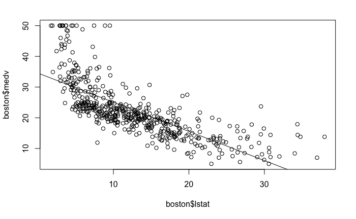

```r
plot(boston$lstat, boston$medv)
abline(model13)
```

# (b) Fit a multiple linear regression models to predict your response using all the predictors. Compare the adjusted R2 from this model with the simple regression model. For which predictors, can we reject the null hypothesis H0 : ??j = 0?

```r
summary(model14)
```

```
Call:
lm(formula = medv ~ ., data = boston)

Residuals:
    Min      1Q  Median      3Q     Max
-15.595  -2.730  -0.518   1.777  26.199

Coefficients:
              Estimate Std. Error t value Pr(>|t|)
(Intercept)  3.646e+01  5.103e+00   7.144 3.28e-12 ***
crim        -1.080e-01  3.286e-02  -3.287 0.001087 **
zn           4.642e-02  1.373e-02   3.382 0.000778 ***
indus        2.056e-02  6.150e-02   0.334 0.738288
chas         2.687e+00  8.616e-01   3.118 0.001925 **
nox         -1.777e+01  3.820e+00  -4.651 4.25e-06 ***
rm           3.810e+00  4.179e-01   9.116  < 2e-16 ***
age          6.922e-04  1.321e-02   0.052 0.958229
dis         -1.476e+00  1.995e-01  -7.398 6.01e-13 ***
rad          3.060e-01  6.635e-02   4.613 5.07e-06 ***
tax         -1.233e-02  3.760e-03  -3.280 0.001112 **
ptratio     -9.527e-01  1.308e-01  -7.283 1.31e-12 ***
black        9.312e-03  2.686e-03   3.467 0.000573 ***
lstat       -5.248e-01  5.072e-02 -10.347  < 2e-16 ***
---
Signif. codes:  0 '***' 0.001 '**' 0.01 '*' 0.05 '.' 0.1 ' ' 1

Residual standard error: 4.745 on 492 degrees of freedom
Multiple R-squared:  0.7406,    Adjusted R-squared:  0.7338
F-statistic: 108.1 on 13 and 492 DF,  p-value: < 2.2e-16
```

The R^2 is much higher than the simple models. We can reject all of the predictors’ H0s besides indus and age at a 5% significance level.

# (c) Create a plot displaying the univariate regression coefficients from (a) on the X-axis and the multiple regression coefficients from (b) on the Y-axis. That is each predictor is displayed as a single point in the plot. Comment on this plot.

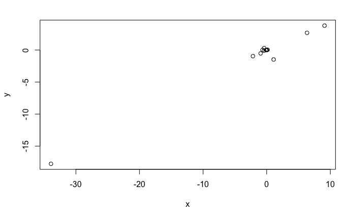

Quite a number of the coefficients are similar to the univariate coefficients. However, there are 3 extremely different ones.

# (d) In this question, we will check if there is evidence of non-linear association between the lstat predictor variable and the response?

To answer the question, fit a model of the form medv = ??0 + ??1lstat + ??2lstat2 + ??. You can make use of the poly() function in R. Does this help improve the fit. Add higher degree polynomial fits. What is the degree of the polynomial fit beyond which the terms no longer remain significant?

```r
summary(model15)
```

```
Call:
lm(formula = medv ~ poly(lstat, degree = 10), data = boston)

Residuals:
     Min       1Q   Median       3Q      Max
-14.5340  -3.0286  -0.7507   2.0437  26.4738

Coefficients:
                            Estimate Std. Error t value Pr(>|t|)
(Intercept)                  22.5328     0.2311  97.488  < 2e-16 ***
poly(lstat, degree = 10)1  -152.4595     5.1993 -29.323  < 2e-16 ***
poly(lstat, degree = 10)2    64.2272     5.1993  12.353  < 2e-16 ***
poly(lstat, degree = 10)3   -27.0511     5.1993  -5.203 2.88e-07 ***
poly(lstat, degree = 10)4    25.4517     5.1993   4.895 1.33e-06 ***
poly(lstat, degree = 10)5   -19.2524     5.1993  -3.703 0.000237 ***
poly(lstat, degree = 10)6     6.5088     5.1993   1.252 0.211211
poly(lstat, degree = 10)7     1.9416     5.1993   0.373 0.708977
poly(lstat, degree = 10)8    -6.7299     5.1993  -1.294 0.196133
poly(lstat, degree = 10)9     8.4168     5.1993   1.619 0.106116
poly(lstat, degree = 10)10   -7.3351     5.1993  -1.411 0.158930
---
Signif. codes:  0 '***' 0.001 '**' 0.01 '*' 0.05 '.' 0.1 ' ' 1

Residual standard error: 5.199 on 495 degrees of freedom
Multiple R-squared:  0.6867,    Adjusted R-squared:  0.6804
F-statistic: 108.5 on 10 and 495 DF,  p-value: < 2.2e-16
```

Higher polynomial fits do help. Beyond 5, however, the terms are no longer significant.